# Final Project Analysis

** Load packages

```r
library(mongolite) # for connecting with Mongo DB
library(e1071) # for Naive Bayes
library(hashmap) # for converting zipcodes to neighborhoods
library(class) # for knn
```

** Utility functions

```r
custMad <- function(pred, actual) {
  # returns the mad given the column of actual values and the column of the predicted values
  # args:
  # - Vector[double] pred; the predicted values from the model of the sale prices
  # - double givenM; the mean of actual values the predicted values are compared to
  # return double mad;
  mad <- sum(abs(pred - actual)) / length(pred)
  return(mad)
}
```

STEP 1: LOAD DATA

Load the proper collection stored in mongo

```r
mongo_conn <- mongo(collection = "apts", db = "apt_db")
test_apts <- mongo_conn$find('{}')
```

Load all of the one bedroom apartments into a dataframe

```r
one_bed_conn <- mongo(collection = "one_beds", db = "apt_db")
raw_one_beds <- one_bed_conn$find('{}')
```

Load all of the two bedroom apartments into a dataframe

```r
two_bed_conn <- mongo(collection = "two_beds", db = "apt_db")
raw_two_beds <- two_bed_conn$find('{}')
```

Load all of the three bedroom apartments into a dataframe

```r
three_bed_conn <- mongo(collection = "three_beds", db = "apt_db")
raw_three_beds <- three_bed_conn$find('{}')
```

Load all of the four and up bedroom apartments into a dataframe

```r
four_plus_conn <- mongo(collection = "four_up_beds", db = "apt_db")
raw_four_beds <- four_plus_conn$find('{}')
```

STEP 2: APPEND AND CLEAN DATA

Append dataframes for all bedrooms

```r
raw_apts <- do.call("rbind", list(raw_one_beds, raw_two_beds, raw_three_beds, raw_four_beds))
```

Clean apartment data

```r
apts <- raw_apts
# convert availability to just months or AvailableNow
apts$Available <- gsub('[[:digit:]]+', '', apts$Available)
apts$Available <- gsub("AvailableNow", "Now", apts$Available)
# alter column data types
apts <- apts[-which(apts$Address=="Boston"),]
apts$SqFt <- gsub("SqFt", "", apts$SqFt)
apts$SqFt <- as.numeric(gsub(",", "", apts$SqFt))
apts$Deposit <- as.numeric(gsub(",", "", apts$Deposit))
apts$Rent <- as.numeric(apts$Rent)
apts$Beds <- factor(apts$Beds)
apts$Baths <- factor(apts$Baths)
apts$Available <- factor(apts$Available)
apts$LeaseLength <- factor(apts$LeaseLength)
apts$City <- factor(apts$City)
apts$State <- factor(apts$State)
apts$Zip <- factor(apts$Zip)
# expand address
apts$Address <- gsub('([[:upper:]])', ' \\1', apts$Address)
# change row names and order
apts <- apts[,c("Address", "City", "State", "Zip", "Unit#", "Rent", "Beds", "Baths", "Available", "LeaseLength", "Deposit", "SqFt")]
names(apts) <- c("Address", "City", "State", "Zip", "Unit", "Rent", "Beds", "Baths", "Available", "LeaseLength", "Deposit", "SqFt")
```

Remove obviously fake information based on industry knowledge / guessing This process is not done using formal outlier detection as it is possible that outliers are legitimate values

```r
# impute deposits that are less than $50 as NA
apts$Deposit[apts$Deposit < 50] <- NA
# impute SqFt where less than 50 or greater than 9950 as NA
apts$SqFt[apts$SqFt < 50 | apts$SqFt > 9950] <- NA
```

Explore the data

```r
summary(apts)
```

```
   Address                       City      State          Zip           Unit                Rent
 Length:2495        Boston         :2467   MA:2495   02135  : 355   Length:2495        Min.   :  750
 Class :character   Brookline      :   5             02130  : 252   Class :character   1st Qu.: 2450
 Mode  :character   Charlestown    :   1             02134  : 181   Mode  :character   Median : 2950
                    Newton         :   2             02128  : 178                      Mean   : 3211
                    RoxburyCrossing:  15             02120  : 175                      3rd Qu.: 3800
                    Somerville     :   5             02119  : 157                      Max.   :21000
                                                     (Other):1197
 Beds        Baths        Available     LeaseLength      Deposit           SqFt
 1:590   1      :1643   Sep    :1211   12     :2403   Min.   :   99   Min.   :  70
 2:596   2      : 595   Now    : 926   6      :   7   1st Qu.: 2200   1st Qu.: 742
 3:634   1.5    : 140   Jun    : 152   1      :   6   Median : 2839   Median :1000
 4:436   3      :  49   May    : 118   14     :   6   Mean   : 3067   Mean   :1071
 5:196   2.5    :  45   Jul    :  52   13     :   5   3rd Qu.: 3700   3rd Qu.:1200
 6: 43   3.5    :  18   Aug    :  25   (Other):  15   Max.   :12000   Max.   :8888
         (Other):   5   (Other):  11   NA's   :  53   NA's   :1260    NA's   :959
```

STEP 3: PREDICT SQUARE FOOTAGE USING A MULTIPLE REGRESSION

View relationsips between square footage and other variables

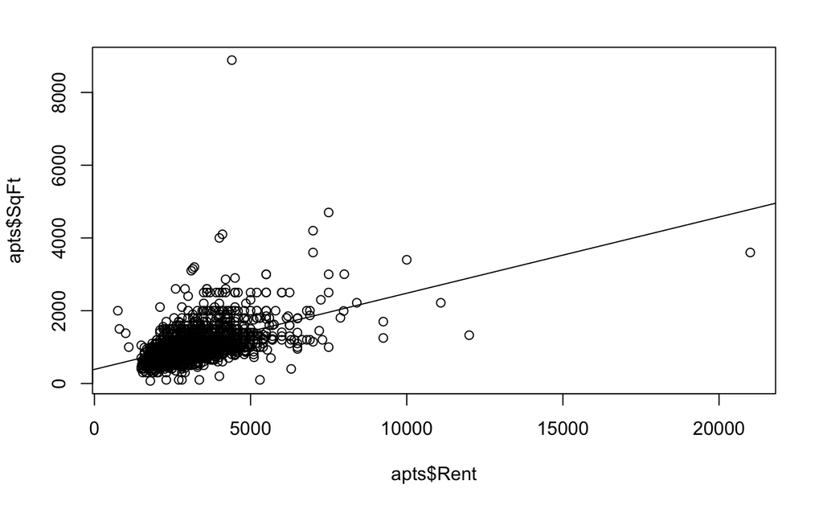

```r
plot(apts$Rent, apts$SqFt)
abline(lm(SqFt ~ Rent, apts))
```

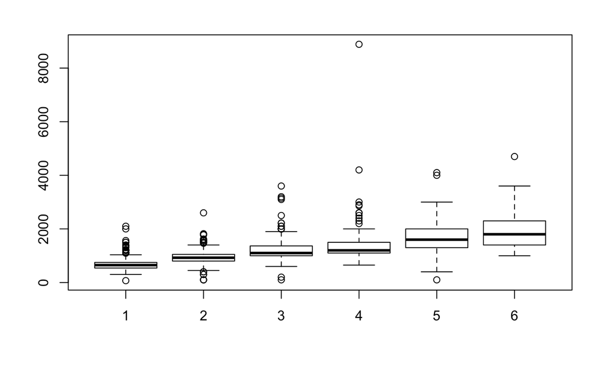

```r
plot(apts$Beds, apts$SqFt)
```

```r
# as expected, both variables show strong positive correlation with SqFt, thus should be included in any model
```

Separate all apartments into those with SqFt info and those without

```r
rowsNa <- which(is.na(apts$SqFt))
wSF <- apts[-rowsNa,]
woSF <- apts[rowsNa,]
```

Run a linear regression to model SqFt as a function of rent, beds, and baths

```r
# address, city, state and unit were not included because they're essentially uniquely identifying
# Used backwards elimination to remove Lease Length
sqft_model <- lm(SqFt ~ Rent + Beds + Baths + Zip, data = wSF)
summary(sqft_model)
```

```
Call:
lm(formula = SqFt ~ Rent + Beds + Baths + Zip, data = wSF)

Residuals:
    Min      1Q  Median      3Q     Max
-1499.5  -163.2   -35.6   112.8  7543.3

Coefficients:
             Estimate Std. Error t value Pr(>|t|)
(Intercept) 388.28513  103.89246   3.737 0.000193 ***
Rent          0.09870    0.01475   6.691 3.12e-11 ***
Beds2       133.15849   29.81362   4.466 8.55e-06 ***
Beds3       285.23519   36.30787   7.856 7.53e-15 ***
Beds4       394.38040   44.00348   8.962  < 2e-16 ***
Beds5       560.37581   60.19377   9.310  < 2e-16 ***
Beds6       671.80595   91.55524   7.338 3.55e-13 ***
Baths1.5     91.33357   45.61541   2.002 0.045438 *
Baths2      107.35573   29.20650   3.676 0.000246 ***
Baths2.5    298.81897   76.83782   3.889 0.000105 ***
Baths3      556.81053   80.46471   6.920 6.68e-12 ***
Baths3.5    513.86480  126.06560   4.076 4.82e-05 ***
Baths4      616.46625  194.39213   3.171 0.001549 **
Baths4.5    733.19610  459.82333   1.595 0.111032
Zip02109    120.68239  136.73186   0.883 0.377583
Zip02110    155.88001  173.03846   0.901 0.367819
Zip02111      2.56969  118.10986   0.022 0.982645
Zip02113    -57.15971  130.40884  -0.438 0.661224
Zip02114    -44.10956  112.55551  -0.392 0.695194
Zip02115    -36.20190  103.56249  -0.350 0.726714
Zip02116    -20.82417  104.92671  -0.198 0.842709
Zip02118     25.00396  104.13213   0.240 0.810272
Zip02119    205.84669  106.85535   1.926 0.054243 .
Zip02120     20.38004  103.65910   0.197 0.844162
Zip02121    311.34435  136.93598   2.274 0.023129 *
Zip02122    220.52414  123.58726   1.784 0.074568 .
Zip02124    209.56769  132.37141   1.583 0.113592
Zip02125    182.13218  113.25468   1.608 0.108011
Zip02126    174.86079  164.89430   1.060 0.289115
Zip02127     45.89178  101.89377   0.450 0.652496
Zip02128    207.18972  106.05725   1.954 0.050939 .
Zip02129     54.19020  106.24236   0.510 0.610083
Zip02130    119.47500  102.28049   1.168 0.242948
Zip02131    341.38075  135.91754   2.512 0.012121 *
Zip02132    257.00828  127.30506   2.019 0.043683 *
Zip02134    138.44135  103.27166   1.341 0.180269
Zip02135    211.48590  100.66480   2.101 0.035818 *
Zip02136    288.54963  213.02106   1.355 0.175763
Zip02145    -18.49368  194.57318  -0.095 0.924290
Zip02210    -48.10029  113.29663  -0.425 0.671225
Zip02215    -59.07022  103.60500  -0.570 0.568663
Zip02446     47.35928  195.74526   0.242 0.808857
Zip02467    214.92344  195.00649   1.102 0.270581
---
Signif. codes:  0 ‘***’ 0.001 ‘**’ 0.01 ‘*’ 0.05 ‘.’ 0.1 ‘ ’ 1

Residual standard error: 378.3 on 1493 degrees of freedom
Multiple R-squared:  0.4937,    Adjusted R-squared:  0.4795
F-statistic: 34.67 on 42 and 1493 DF,  p-value: < 2.2e-16
```

Use the SqFt model to impute NAs in the SqFt column

```r
# create dataframe for apartments including imputed values and engineered fields
# dataframe does not inlude the 'Deposit' fields because most values are missing and its information is irrelevant regardless becuase it is almost always the same as rent
eng_apts <- apts[,!(names(apts) == "Deposit")]
eng_apts$SqFt[which(is.na(eng_apts$SqFt))] <- predict(sqft_model, newdata = eng_apts[which(is.na(eng_apts$SqFt)),], type = "response")
```

Create a derived feature ‘Size’ that describes an apartment as ‘small’, ‘average’, or ‘large’

```r
# for each number of beds:
# find the lower and upper quartiles for sqft
# if sqft is below the 1st quartile then it is 'small'
# if sqft is between the 1st and 3rd quartile then it is 'average'
# if sqft is greater than the 3rd quartile then it is 'large'
sorted_beds <- sort(unique(eng_apts$Beds), decreasing = FALSE)
eng_apts$Size <- NA
for(bed in sorted_beds) {
  next_sqft <- eng_apts$SqFt[which(eng_apts$Beds==bed)]
  quart <- quantile(next_sqft, c(.25, .75), type = 1)
  quart <- unname(quart)
  eng_apts$Size[which(eng_apts$Beds==bed)] = sapply(eng_apts$SqFt[which(eng_apts$Beds==bed)], function(x)
  {if(x < quart[1]) {
    return("Small")
    } else if(x >= quart[1] & x <= quart[2]) {
      return("Average")
    } else if (x > quart[2]){
      return("Large")
    } else {
      return(NA)
    }})
}
eng_apts$Size <- factor(eng_apts$Size)
```

Create a derived feature ‘Price’ that describes an apartment as ‘cheap’, ‘average’, or ‘expensive’

```r
# for each number of beds:
# find the lower and upper quartiles for rent
# if rent is below the 1st quartile then it is 'cheap'
# if rent is between the 1st and 3rd quartile then it is 'average'
# if rent is greater than the 3rd quartile then it is 'expensive'
sorted_beds <- sort(unique(eng_apts$Beds), decreasing = FALSE)
eng_apts$Price <- NA
for(bed in sorted_beds) {
  next_price <- eng_apts$Rent[which(eng_apts$Beds==bed)]
  quart <- quantile(next_price, c(.25, .75), type = 1)
  quart <- unname(quart)
  eng_apts$Price[which(eng_apts$Beds==bed)] = sapply(eng_apts$Rent[which(eng_apts$Beds==bed)], function(x)
  {if(x < quart[1]) {
    return("Cheap")
    } else if(x >= quart[1] & x <= quart[2]) {
      return("Average")
    } else if (x > quart[2]){
      return("Expensive")
    } else {
      return(NA)
    }})
}
eng_apts$Price <- factor(eng_apts$Price)
```

STEP 3: PREDICT NEIGHBORHOOD OF EACH APARTMENT